# UN exploration

```r
library(tidyverse)
```

```r
gdp_df <- read_csv('./data/gdp_per_capita.csv')
```

```r
gdp_df |> head()
```

| Country or Area | Year | Value | Value Footnotes |
| --- | --- | --- | --- |
| Afghanistan | 2020 | 1970.560 | NA |
| Afghanistan | 2019 | 2065.036 | NA |
| Afghanistan | 2018 | 2033.804 | NA |
| Afghanistan | 2017 | 2058.400 | NA |
| Afghanistan | 2016 | 2057.068 | NA |
| Afghanistan | 2015 | 2068.266 | NA |

Drop the ‘Value Footnotes’ column, and rename the remaining columns to ‘Country’, ‘Year’, and ‘GDP_Per_Capita’.

```r
gdp_df <- gdp_df |> select("Country or Area", "Year","Value")
```

```r
gdp_df <- gdp_df |>
  rename(
    Country = `Country or Area`,
    Year = Year,
    GDP_Per_capita = Value
  )
```

Which years are represented in this dataset? How many observations are there per year? Make a plot to view the number of observations per year.

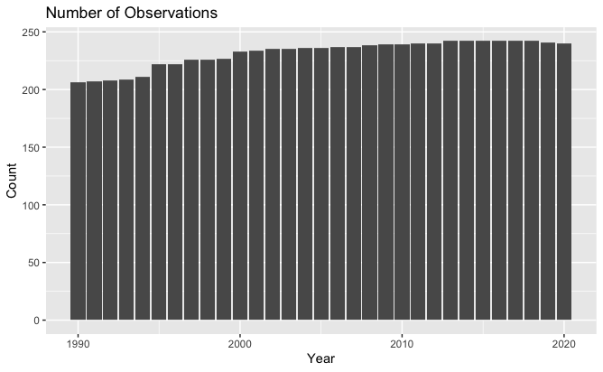

```r
gdp_df |>
  group_by(Year) |>
  summarise(Count = n()) |>
  ggplot(aes(x=Year, y=Count)) +
           geom_bar(stat = "identity") +
           labs(title = "Number of Observations", x="Year", y="Count")
```

How many countries are represented in this dataset?

```r
gdp_df |>
  summarise(Countries = n_distinct(Country))
```

| Countries |
| --- |
| 242 |

Which countries have the fewest observations?

```r
gdp_df |>
  group_by(Country) |>
  summarise(Count = n()) |>
  arrange(Count)
```

| Country | Count |
| --- | --- |
| Djibouti | 8 |
| Somalia | 8 |
| Sint Maarten (Dutch part) | 10 |
| Turks and Caicos Islands | 10 |
| Kosovo | 13 |
| Cayman Islands | 15 |
| Nauru | 17 |
| Afghanistan | 19 |
| São Tomé and Principe | 20 |
| Curaçao | 21 |

[output cut: 232 more lines]

Create a new dataframe by subsetting gdp_df to just the year 2014. Call this new dataframe gdp_2014.

```r
gdp_df_2014 <- filter(gdp_df, Year == 2014)
gdp_df_2014 |> head()
```

| Country | Year | GDP_Per_capita |
| --- | --- | --- |
| Afghanistan | 2014 | 2102.385 |
| Africa Eastern and Southern | 2014 | 3677.319 |
| Africa Western and Central | 2014 | 4215.646 |
| Albania | 2014 | 11586.834 |
| Algeria | 2014 | 11512.690 |
| Angola | 2014 | 8240.348 |

Use .describe() to find the summary statistics for GDP per capita in 2014.

```r
summary(gdp_df_2014$GDP_Per_capita)
```

```
    Min.  1st Qu.   Median     Mean  3rd Qu.     Max.
   822.6   4702.2  12178.9  19612.9  26461.4 155201.7
```

Create a histogram of GDP Per Capita numbers for 2014 (you may wish to adjust the number of bins for your histogram).

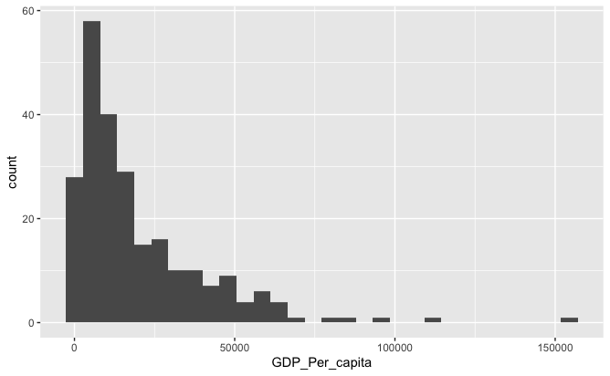

```r
gdp_df_2014 |>
  ggplot(aes(x = GDP_Per_capita)) +
  geom_histogram(bins=30)
```

Find the top 5 counties and bottom 5 countries by GDP per capita in 2014.

```r
gdp_df_2014 |>
   arrange(GDP_Per_capita) |>
  head()
```

| Country | Year | GDP_Per_capita |
| --- | --- | --- |
| Central African Republic | 2014 | 822.6112 |
| Burundi | 2014 | 886.2353 |
| Somalia | 2014 | 917.8765 |
| Dem. Rep. Congo | 2014 | 1029.7908 |
| Niger | 2014 | 1126.8054 |
| Mozambique | 2014 | 1217.0889 |

```r
gdp_df_2014 |>
   arrange(desc(GDP_Per_capita)) |>
  head()
```

| Country | Year | GDP_Per_capita |
| --- | --- | --- |
| Macao SAR, China | 2014 | 155201.74 |
| Luxembourg | 2014 | 113313.58 |
| Qatar | 2014 | 95578.26 |
| Singapore | 2014 | 87616.64 |
| Bermuda | 2014 | 77361.10 |
| Switzerland | 2014 | 67682.69 |

Now, return to the full dataset, gdp_df. Pivot the data for 1990 and 2018 (using the pandas .pivot_wider() method or another method) so that each row corresponds to a country, each column corresponds to a year, and the values in the table give the GDP_Per_Capita amount. Drop any rows that are missing values for either 1990 or 2018. Save the result to a dataframe named gdp_pivoted.

```r
gdp_pivoted <- gdp_df |>
  filter(Year %in% c(1990, 2018)) |>
  pivot_wider(names_from = Year, values_from = GDP_Per_capita ) |>
  na.omit()
```

Create a new column in gdp_pivoted named Percent_Change. This column should contain the percent change in GDP_Per_Capita from 1990 to 2018. Hint: Percent change is calculated as 100*(New Value - Old Value) / Old Value.

```r
gdp_pivoted = gdp_pivoted |>
  mutate(Percent_Change = 100*(`2018`-`1990`)/`1990`)
```

How many countries experienced a negative percent change in GDP per capita from 1990 to 2018?

```r
gdp_pivoted |>
  filter(Percent_Change<0) |>
  nrow()
```

```
[1] 17
```

Which country had the highest % change in GDP per capita? Create a line plot showing these country’s GDP per capita for all years for which you have data. Put both line charts on the same plot.

```r
gdp_pivoted |>
  arrange(desc(Percent_Change)) |>
  head(2)
```

| Country | 2018 | 1990 | Percent_Change |
| --- | --- | --- | --- |
| Equatorial Guinea | 20386.01 | 1039.985 | 1860.222 |
| China | 15134.00 | 1423.896 | 962.858 |

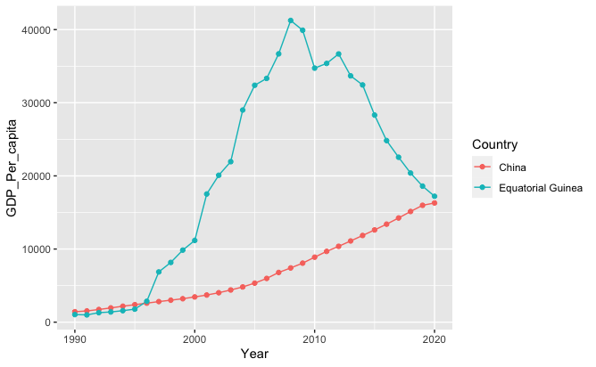

```r
china <- filter(gdp_df, Country == "China"  & !is.na(GDP_Per_capita))
eq_guinea <- filter(gdp_df, Country == "Equatorial Guinea"  & !is.na(GDP_Per_capita))
combined_data <- rbind(china, eq_guinea)
ggplot(data = combined_data, aes(x = Year, y = GDP_Per_capita, color = Country)) +
  geom_line() +
  geom_point()
```

Read in continents.csv contained in the data folder into a new dataframe called continents. We will be using this dataframe to add a new column to our dataset.

Merge gdp_df and continents. Keep only the countries that appear in both data frames. Save the result back to gdp_df.

```r
continents <- read_csv('./data/continents.csv')
```

```r
continents |> head()
```

| Continent | Country |
| --- | --- |
| Asia | Afghanistan |
| Europe | Albania |
| Africa | Algeria |
| Europe | Andorra |
| Africa | Angola |
| North America | Antigua and Barbuda |

```r
 gdp_df <- inner_join(gdp_df, continents,
           by = c("Country"))
```

Determine the number of countries per continent. Create a bar chart showing this.

[figure not shown]

```r
gdp_df |>
  group_by(Continent) |>
  summarise(num_countries = n()) |>
  ggplot(aes(x=Continent, y=num_countries)) +
  geom_bar(stat="identity", fill="skyblue", color="black") +
  labs(title ="Number of Countries in Each Continent", x="Continent", y="Number of Countries")
```

```r
life_expectancy <- read_csv('./data/life_expectancy.csv',skip=4)
```

```r
life_expectancy <- select(life_expectancy, -c("Country Code", "Indicator Name", "Indicator Code"))

life_expectancy <- life_expectancy |> rename(
    Country = `Country Name`,
  )
life_expectancy |> head()
```

| Country | 1960 | 1961 | 1962 | 1963 | 1964 | 1965 | 1966 | 1967 | 1968 | 1969 | 1970 | 1971 | 1972 | 1973 | 1974 | 1975 | 1976 | 1977 | 1978 | 1979 | 1980 | 1981 | 1982 | 1983 | 1984 | 1985 | 1986 | 1987 | 1988 | … |
| --- | --- | --- | --- | --- | --- | --- | --- | --- | --- | --- | --- | --- | --- | --- | --- | --- | --- | --- | --- | --- | --- | --- | --- | --- | --- | --- | --- | --- | --- | --- |
| Aruba | 64.15200 | 64.53700 | 64.75200 | 65.13200 | 65.29400 | 65.50200 | 66.06300 | 66.43900 | 66.75700 | 67.16800 | 67.58300 | 67.97500 | 68.57700 | 69.09200 | 69.50300 | 69.76200 | 70.03500 | 70.26400 | 70.49400 | 70.77800 | 71.06600 | 71.72200 | 71.95900 | 72.10500 | 72.25100 | 72.38800 | 72.46200 | 72.78900 | 73.04700 | … |
| Africa Eastern and Southern | 44.08555 | 44.38670 | 44.75218 | 44.91316 | 45.47904 | 45.49834 | 45.24910 | 45.92491 | 46.22310 | 46.43230 | 46.71848 | 47.19294 | 46.89739 | 47.69232 | 47.59806 | 47.75989 | 48.34959 | 48.63591 | 48.76360 | 49.26134 | 49.63654 | 50.05707 | 50.29685 | 48.70333 | 48.65266 | 49.01163 | 49.63972 | 50.07589 | 49.35973 | … |
| Afghanistan | 32.53500 | 33.06800 | 33.54700 | 34.01600 | 34.49400 | 34.95300 | 35.45300 | 35.92400 | 36.41800 | 36.91000 | 37.41800 | 37.92300 | 38.44400 | 39.00300 | 39.55000 | 40.10000 | 40.64500 | 41.22800 | 40.27100 | 39.08600 | 39.61800 | 40.16400 | 37.76600 | 38.18700 | 33.32900 | 33.55000 | 39.39600 | 39.84400 | 43.95800 | … |
| Africa Western and Central | 37.84515 | 38.16495 | 38.73510 | 39.06372 | 39.33536 | 39.61804 | 39.83783 | 39.47150 | 40.08568 | 40.35042 | 41.03476 | 41.55672 | 42.24979 | 42.85505 | 43.49768 | 44.20125 | 45.00316 | 45.71989 | 46.26954 | 46.67374 | 47.01524 | 47.29719 | 47.52938 | 47.78526 | 47.93192 | 48.02168 | 48.06676 | 48.23785 | 48.51291 | … |
| Angola | 38.21100 | 37.26700 | 37.53900 | 37.82400 | 38.13100 | 38.49500 | 38.75700 | 39.09200 | 39.48400 | 39.82900 | 40.19000 | 40.55400 | 40.90500 | 41.27000 | 41.65200 | 41.19100 | 41.16300 | 41.43700 | 41.83000 | 42.17500 | 42.44900 | 42.77200 | 43.05100 | 42.09200 | 42.35300 | 42.64800 | 42.84300 | 40.91700 | 41.54500 | … |
| Albania | 54.43900 | 55.63400 | 56.67100 | 57.84400 | 58.98300 | 60.01900 | 60.99800 | 61.97200 | 62.94600 | 63.92300 | 64.82400 | 65.61800 | 66.42200 | 67.14000 | 67.76900 | 68.32800 | 68.70400 | 69.12100 | 69.30900 | 69.58400 | 70.47800 | 70.73000 | 71.02300 | 71.29600 | 71.50200 | 71.65600 | 71.95000 | 72.35200 | 72.64100 | … |

```r
life_expectancy <- life_expectancy |>
  pivot_longer(!Country, names_to = "Year", values_to = "Life_Expectancy")
```

```r
life_expectancy |>
  filter(Life_Expectancy > 80) |>
  arrange(Year)
```

| Country | Year | Life_Expectancy |
| --- | --- | --- |
| Japan | 1996 | 80.21976 |
| Gibraltar | 1997 | 80.34300 |
| Hong Kong SAR, China | 1997 | 80.12683 |
| Japan | 1997 | 80.42415 |
| Macao SAR, China | 1997 | 80.16200 |
| Gibraltar | 1998 | 80.66300 |
| Hong Kong SAR, China | 1998 | 80.13171 |
| Japan | 1998 | 80.50146 |
| Macao SAR, China | 1998 | 80.35200 |
| Gibraltar | 1999 | 81.53300 |

[output cut: 643 more lines]

```r
NA
```

```r
life_expectancy <- life_expectancy |> mutate(Year = as.numeric(Year))
```

```r
gdp_le <-inner_join(gdp_df, life_expectancy,
           by = c("Country", "Year"))
```

```r
gdp_le |> tail()
```

| Country | Year | GDP_Per_capita | Continent | Life_Expectancy |
| --- | --- | --- | --- | --- |
| Zimbabwe | 1995 | 2573.994 | Africa | 50.531 |
| Zimbabwe | 1994 | 2603.927 | Africa | 52.588 |
| Zimbabwe | 1993 | 2420.093 | Africa | 54.426 |
| Zimbabwe | 1992 | 2437.153 | Africa | 56.435 |
| Zimbabwe | 1991 | 2733.697 | Africa | 58.091 |
| Zimbabwe | 1990 | 2652.129 | Africa | 59.426 |

```r
gdp_le_2019 <- gdp_le |> filter(Year == 2019)
```

```r
gdp_le_2019 |> filter(Life_Expectancy >= 80) |>
  summarize(Count = n())
```

| Count |
| --- |
| 34 |

```r
gdp_le_2019 |> arrange(desc(GDP_Per_capita)) |> slice(1:3)
```

| Country | Year | GDP_Per_capita | Continent | Life_Expectancy |
| --- | --- | --- | --- | --- |
| Macao SAR, China | 2019 | 127272.55 | Asia | 84.97800 |
| Luxembourg | 2019 | 116518.28 | Europe | 82.63902 |
| Singapore | 2019 | 98283.31 | Asia | 83.59512 |

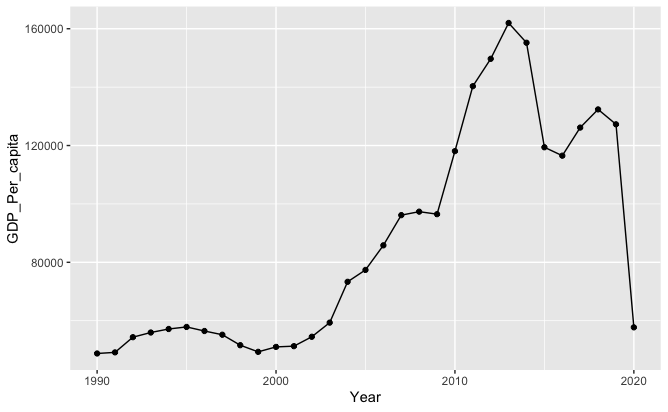

```r
macao <- gdp_le |>
  filter(Country == "Macao SAR, China") |>
  ggplot(aes(x = Year, y = GDP_Per_capita)) +
  geom_point() + geom_line()

# Show the plot
print(macao)
```

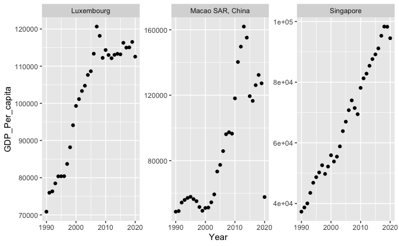

```r
countries <- c("Macao SAR, China", "Luxembourg", "Singapore")
filtered_data <- gdp_le |> filter(Country %in% countries)
plot <- ggplot(data = filtered_data, aes(x= Year, y=GDP_Per_capita)) + geom_point() + facet_wrap(~Country, scales = "free")
print(plot)
```

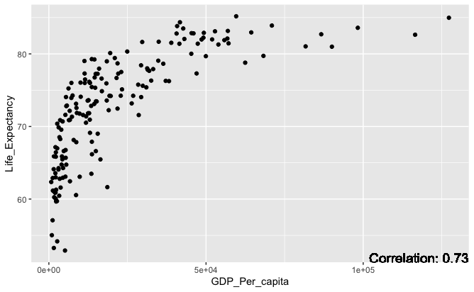

```r
gdp_le_2019_cleaned <- na.omit(gdp_le_2019)
correlation <- cor(gdp_le_2019_cleaned$GDP_Per_capita, gdp_le_2019_cleaned$Life_Expectancy)
plot <- ggplot(data=gdp_le_2019_cleaned, aes(x=GDP_Per_capita, y=Life_Expectancy))+geom_point()+geom_text(x = Inf, y = -Inf, label = paste("Correlation:", round(correlation, 2)),
            hjust = 1, vjust = 0, size = 5,
            aes(label = paste("Corr:", round(correlation, 2))))
print(plot)
```

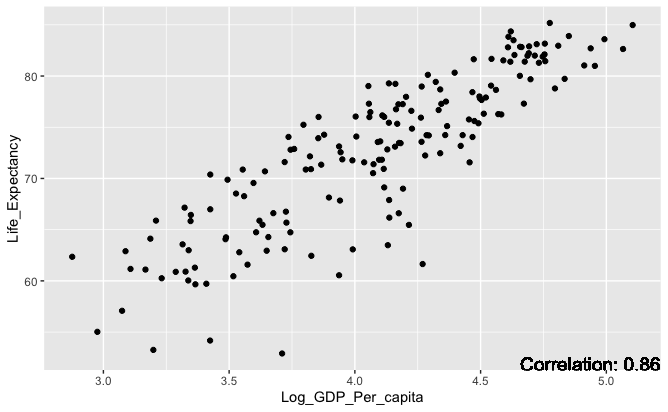

```r
gdp_le_2019 <- na.omit(gdp_le_2019)
gdp_le_2019 <- gdp_le_2019 |> mutate(Log_GDP_Per_capita = log10(GDP_Per_capita))
correlation <- cor(gdp_le_2019$Log_GDP_Per_capita, gdp_le_2019$Life_Expectancy)
plot <- ggplot(data=gdp_le_2019, aes(x=Log_GDP_Per_capita, y=Life_Expectancy))+geom_point()+geom_text(x = Inf, y = -Inf, label = paste("Correlation:", round(correlation, 2)),
            hjust = 1, vjust = 0, size = 5,
            aes(label = paste("Corr:", round(correlation, 2))))
print(plot)
```

```r
NA
NA
NA
NA
```